# Введение в анализ данных

### Пакеты

R появился в 1993 году. Его “ядро” устаревает, но мир не стоит на месте и постоянно развивается. Следовательно, нужно вносить какие-то изменения в язых: улучшать и оптимизировать его функционал и так далее. Но изменение ядра может повлечь за собой серьезные последствия. Поэтому было принято не менять изначальный функционал, а создавать новые функции и методы. Функций очень много, и подгружать их все нет смысла. Для этого придумали пакеты(библиотеки), в которых лежат функции и многое другое, которые можно установить и начать ими пользоваться. Все пакеты распространяются через CRAN (Comprehensive R Archive Network).

Мы будем постоянно работать с различными пакетами, поэтому давайте научимся их устанавливать. Сначала нужно скачать пакет на наш компьютер, это нужно сделать только один раз. Сделать это можно с помощью функции `install.packages()`. Аргументом этой функции является название пакета в кавычках. Давайте установим пакет `dplyr`, который нужен для работы с набором данных.

```r
install.packages('dplyr')
```

Отлично! Мы скачали пакет на свой компьютер. Чтобы начать пользоваться функционалом пакета, нужно подгрузить его с помощью команды `library()`. Аргументом этой функции также является название пакета, но вводить можно уже без кавычек. Эту команду нужно выполнять каждый раз, как вы заходите в RStudio и хотите воспользоваться функционалом пакета.

```r
library('dplyr')
```

В нижнем правов окне есть вкладка “Packages”. В ней можно установить пакеты с помощью кнопки “Install”, обновить пакеты с помощью кнопки “Update”, а также увидеть список установленных пакетов на вашем компьютере. Галочкой отмечены пакеты, которые подгружены в данный момент.

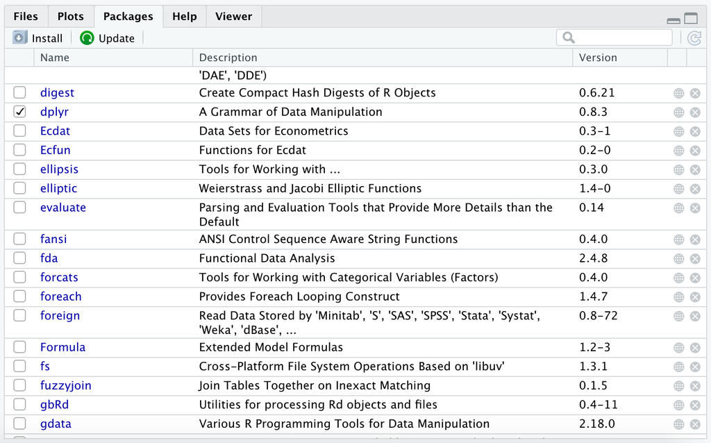

### Типы переменных

**Переменная** – это самый простой тип данных в R. Вы можете сохранить какое-либо значение под определённым названием. Помним, что название должно соблюдать некоторые правила.

К текущему моменту мы знаем следующие типы переменных в R:

1. Числовой(numeric/integer/double)
2. Строковый(character)
3. Логический(logical)
4. `NA`(not available)
5. `NaN`(not a number)

```r
(number <- 5)
## [1] 5
(name <- 'Ahmedushka')
## [1] "Ahmedushka"
(log <- TRUE)
## [1] TRUE
(na <- NA)
## [1] NA
(nan <- NaN)
## [1] NaN
```

Тип переменной всегда можно проверить с помощью функций `class()` и `typeof()`, а также семейства функций `is.*`. `NA` имеет на самом деле логический тип, а `NaN` числовой тип. Но их стоит выделять отдельно.

```r
class(number)
## [1] "numeric"
class(name)
## [1] "character"
class(log)
## [1] "logical"
class(na)
## [1] "logical"
class(nan)
## [1] "numeric"
```

Иногда нужно менять тип переменной. Для этого используется семейство функций `as.*`.

- `as.numeric(as.integer)`
- `as.character`
- `as.logical`

Создадим строковую переменную `n` равную “10”.

```r
n <- "10"
class(n)
```

```
## [1] "character"
```

С такой переменной нельзя даже выполнить какие-либо арифметические операции. Поэтому преобразуем ее к числовому типу.

```r
n <- as.numeric(n)
class(n)
```

```
## [1] "numeric"
```

Семейство функций может работать и с массивами.

```r
(x <- 1:5)
## [1] 1 2 3 4 5
(y <- as.character(x))
## [1] "1" "2" "3" "4" "5"
(class(x))
## [1] "integer"
(class(y))
## [1] "character"
```

Рассмотрим еще два типа переменных:

- Категориальный или факторный(factor)
- Дата и время (date)

#### Факторный тип переменных

Факторный тип переменных – это фиксированны набор строковых переменных, на которых можно установить какой-то порядок, то есть сравнить друг с другом эти строковые переменные.

Например, название месяцев. Их фиксированное количество(12) и на них установлен порядок: февраль(2) > январь(1).

Давайте разбремся зачем нужны факторные переменные. Представьте, что у вас есть массив, в котором записаны названия месяцев.

```r
year1 <- c('Dec', 'Jan', 'Apr', 'Mar')
```

При использовании обычного массива у вас возникают 2 проблемы:

1. Этот список сортируется в алфавитном порядке, а не в том порядке, который мы хотели бы:

```r
sort(year1)
```

```
## [1] "Apr" "Dec" "Jan" "Mar"
```

2. Возможны опечатки:

```r
year2 <- c('Dec', 'Jam', 'Apr', 'Mar')
```

Эти 2 проблемы можно избежать с помощью факторного типа переменных. Он создается с помощью функции `factor`. Также у этой функции есть аргумент `levels`, в который можно передать список допустимых значений и порядок:

```r
months <- c('Jan', 'Feb', 'Mar', 'Apr', 'May', 'Jun', 'Jul', 'Aug', 'Sep', 'Oct', 'Nov', 'Dec')
year1_2 <- factor(year1, levels = months)
year2_2 <- factor(year2, levels = months)
class(year1_2)
```

```
## [1] "factor"
```

Если мы совершим ошибку, то выставится значение `NA`. А теперь попробуем отсортировать наш фактор.

```r
sort(year1_2)
```

```
## [1] Jan Mar Apr Dec
## Levels: Jan Feb Mar Apr May Jun Jul Aug Sep Oct Nov Dec
```

Для создания факторного типа, можно испольовать функцию `as.factor()`.

#### Тип переменной дата и время

```r
(date <- Sys.Date())
## [1] "2020-09-29"
(time <- Sys.time())
## [1] "2020-09-29 22:56:01 MSK"
(class(date))
## [1] "Date"
(class(time))
## [1] "POSIXct" "POSIXt"
```

Обычно время дано в виде строковой переменной. С помощью базовых функций `as.Date()` и `as.POSIXct()` можно создавать переменные типа дата и время. Но мы не будем пользоваться этими старыми не очень удорбными функциями. Мы будем использовать современные функции из пакета `lubridate`, который предназначен для работы со временем. Давайте установим и подгрузим этот пакет.

```r
# install.packages('lubridate')
library('lubridate')
```

Рассмотрим основные функции в этом пакете:

- `dmy`
- `dym`
- `mdy`
- `myd`
- `ymd`
- `ydm`

Все эти функции расшифровываются как day month year, только в разном порядке. Эти функции позволяют из строковой или числовой переменной получить переменную с типом дата. Порядок букв означает в каком порядке представлена дата. Если в дате сначала идет день, потом месяц и потом год, то нужно использовать функцию `dmy`. Давайте попробуем.

```r
(mdy("January 18 2005"))
## [1] "2005-01-18"
(ymd('01/02/03'))
## [1] "2001-02-03"
(d <- dmy(10092018))
## [1] "2018-09-10"
(class(d))
## [1] "Date"
```

Все даты приведены к формату “year-month-day”. Эти функции могут работать и с массивами.

```r
x <- c("09-01-01", "09-01-02", "09-01-03")
ymd(x)
```

```
## [1] "2009-01-01" "2009-01-02" "2009-01-03"
```

Мы еще более подробно поговорим о пакете `lubridate` и о работе с факторными переменными.

### Контейнеры для хранения данных

Перед тем как мы начнем познавать анализ данных, давайте вспомним какие контейнеры для хранения данных мы изучили:

1. Переменная
2. Массив(вектор)
3. Матрица

Про каждый из контейнеров мы говорили. Давайте только вспомним, что массив может состоять только из переменных одного типа. Матрица – это двумерный массив, поэтому тоже может состоять только из переменных одного типа.

### Формат данных для анализа

То, как должны выглядеть данные зависит от задачи. Мы можем работать с временными рядами, картинками, видео и многим другим. От того с какими данными мы работаем, зависит как они должны выглядеть. В этом курсе мы будем работать с данными типа наблюдения(observations) – переменные(variables). Давайте рассмотрим эту концепцию на примере.

| Name | Age | Gender | Birthday | Homework grade |
| --- | --- | --- | --- | --- |
| Jack | 19 | M | 10 May 2000 | A |
| Emma | 21 | F | 22 February 1998 | B+ |
| Henry | 18 | M | 3 September 2001 | C- |
| Aria | 20 | F | 26 June 1999 | D |

В этом наборе данных каждая строчка это наблюдение о каком-то человеке. А какждый столбце это переменная, которая описывает какую-то характеристику людей. Важно заметить, что столбцы – это массивы, так как они содержат один тип переменных.

- `Name` – строковый(character)
- `Age` – числовой(numeric)
- `Gender` – категориальный(без порядка)(factor)
- `Birthday` – дата(date)
- `Homework grade` – категориальный(с порядком)(factor)

То есть, набор данных – это набор массивов с разным типом переменных. Матрица, как говорилось ранее, не подходит под это описание. Для хранения такого набора данных был придуман *data frame*(дата фрейм или фрейм данных), коротко *df*. Грубо говоря, это матрица, состоящая из массивов рызных типов переменных.

### Data Frame

Давайте создадим наш первый `data frame`. Для этого нам нужна функция `data.frame`, в которой мы даем название нашим переменным и передаем массив значений. Создадим набор данных, который разбирали выше.

```r
df <- data.frame('Name' = c('Jack', 'Emma', 'Henry', 'Aria'),
                   'Age' = c(19, 21, 18, 20),
                   'Gender' = c('M', 'F', 'M', 'F'),
                   'Birthday' = c('10 May 2000', '22 February 1998',
                                  '3 September 2001', '26 June 1999'),
                   'Homework grade' = c('A', 'B+', 'C-', 'D'),
                   stringsAsFactors = FALSE)
print(df)
```

```
##    Name Age Gender         Birthday Homework.grade
## 1  Jack  19      M      10 May 2000              A
## 2  Emma  21      F 22 February 1998             B+
## 3 Henry  18      M 3 September 2001             C-
## 4  Aria  20      F     26 June 1999              D
```

При использовании функции, мы установили аргумент `stringsAsFactors = FALSE`, чтобы строковые переменные не форматировались в факторные.

```r
View(df)
```

Заметим, что название переменной “Homework grade” изменилось на “Homework.grade”. Это происхоит, потому что data frame запрещает иметь в названии пробелы, а также он запрещает называть переменные, начиная с цифр или символов.

Давайте начнем работать с нашим набором данных. Во-первых, давайте убедимся, что перед нами правда df. Сделаем это с помощью функции `class`.

```r
class(df)
```

```
## [1] "data.frame"
```

Давайте посмотрим на размерность нашего df. Для этого используем функции `nrow()` и `ncol()`.

```r
(nrow(df)) # количество наблюдений
## [1] 4
(ncol(df)) # количество переменных
## [1] 5
```

Видим, что у нас есть 4 наблюдения и 5 переменных. Чтобы получить эти два числа сразу, можно использовать функцию `dim()`.

```r
dim(df)
```

```
## [1] 4 5
```

Фреймы данных бывают очень большие, поэтмому посмотреть вручную столбцы и наблюения бывает сложно. Когда вы только начинаете работать с таким df, лучше сначала использовать функцию `str`. Она показывает его структуру.

```r
str(df)
```

```
## 'data.frame':    4 obs. of  5 variables:
##  $ Name          : chr  "Jack" "Emma" "Henry" "Aria"
##  $ Age           : num  19 21 18 20
##  $ Gender        : chr  "M" "F" "M" "F"
##  $ Birthday      : chr  "10 May 2000" "22 February 1998" "3 September 2001" "26 June 1999"
##  $ Homework.grade: chr  "A" "B+" "C-" "D"
```

Можно увидеть уже знакомую нам информацию, что мы имеем дело с df, у которого 4 наблюдения и 5 переменных, а также информацию по каждому столбцу(переменной). После названия столбца(переменной) идет тип переменных в нем.

Обратиться к какой-то переменной можно с помощью $. Сначала пишем название df, потом ставим $ и пишем название переменной, данные по которой мы хотим получить.

```r
df$Age # массив, состоящий из значений возраста
```

```
## [1] 19 21 18 20
```

При создании df, мы не использовали только строковый и числовой тип переменных. Чтобы работать с нужными типами переменных, используем функции, которые изучили ранее.

```r
df$Gender <- factor(df$Gender)
df$Birthday <- dmy(df$Birthday)
df$Homework.grade <- factor(df$Homework.grade,
                              levels = c('A', 'A-', 'B+', 'B', 'B-', 'C+', 'C',
                                         'C-', 'D+', 'D', 'E', 'F'))
```

Посмотрим теперь на структуру нашего df.

```r
str(df)
```

```
## 'data.frame':    4 obs. of  5 variables:
##  $ Name          : chr  "Jack" "Emma" "Henry" "Aria"
##  $ Age           : num  19 21 18 20
##  $ Gender        : Factor w/ 2 levels "F","M": 2 1 2 1
##  $ Birthday      : Date, format: "2000-05-10" "1998-02-22" ...
##  $ Homework.grade: Factor w/ 12 levels "A","A-","B+",..: 1 3 8 10
```

Наш датасет(df) очень маленький. В R и его пакетах есть встроенные датасеты. Давайте воспользуемся датасетом `mtcars`. Об этом датасете можно подробнее прочитать с помощью команды `?mtcars`. Этот датасет о характеристиках машин 1974 года.

Можно написать в консоли `mtcars`, и мы увидим этот датасет. Но лучше подгрузить его, чтобы мы видели его в верхнем правом окне. Это можно сделать с помощью функции `data`.

```r
data(mtcars)
```

Изучим структуру набора данных.

```r
str(mtcars)
```

```
## 'data.frame':    32 obs. of  11 variables:
##  $ mpg : num  21 21 22.8 21.4 18.7 18.1 14.3 24.4 22.8 19.2 ...
##  $ cyl : num  6 6 4 6 8 6 8 4 4 6 ...
##  $ disp: num  160 160 108 258 360 ...
##  $ hp  : num  110 110 93 110 175 105 245 62 95 123 ...
##  $ drat: num  3.9 3.9 3.85 3.08 3.15 2.76 3.21 3.69 3.92 3.92 ...
##  $ wt  : num  2.62 2.88 2.32 3.21 3.44 ...
##  $ qsec: num  16.5 17 18.6 19.4 17 ...
##  $ vs  : num  0 0 1 1 0 1 0 1 1 1 ...
##  $ am  : num  1 1 1 0 0 0 0 0 0 0 ...
##  $ gear: num  4 4 4 3 3 3 3 4 4 4 ...
##  $ carb: num  4 4 1 1 2 1 4 2 2 4 ...
```

Видим, что имеется 32 наблюдения и 11 переменных, все из которых числовые. Когда датасет очень большой, неудобно просматривать его весь. Обычно смотрят на первые и последние 6 наблюдений с помощью функций `head` и `tail`. Можно выводить другое количество наблюдений на экран с помощью парметра `n`.

```r
head(mtcars)
```

```
##                    mpg cyl disp  hp drat    wt  qsec vs am gear carb
## Mazda RX4         21.0   6  160 110 3.90 2.620 16.46  0  1    4    4
## Mazda RX4 Wag     21.0   6  160 110 3.90 2.875 17.02  0  1    4    4
## Datsun 710        22.8   4  108  93 3.85 2.320 18.61  1  1    4    1
## Hornet 4 Drive    21.4   6  258 110 3.08 3.215 19.44  1  0    3    1
## Hornet Sportabout 18.7   8  360 175 3.15 3.440 17.02  0  0    3    2
## Valiant           18.1   6  225 105 2.76 3.460 20.22  1  0    3    1
```

```r
tail(mtcars, n = 3)
```

```
##                mpg cyl disp  hp drat   wt qsec vs am gear carb
## Ferrari Dino  19.7   6  145 175 3.62 2.77 15.5  0  1    5    6
## Maserati Bora 15.0   8  301 335 3.54 3.57 14.6  0  1    5    8
## Volvo 142E    21.4   4  121 109 4.11 2.78 18.6  1  1    4    2
```

Датасет очень похож на матрицу. Он тоже двумерный, поэтому к нему можно обращаться как к матрице. Давайте найдем значение в 1 строке(наблюдении), во 2 столбце(переменной). Выведем полностью 1 строку(наблюдение) и 3 столбец(переменную).

```r
mtcars[1, 2]
## [1] 6
mtcars[1, ]
##           mpg cyl disp  hp drat   wt  qsec vs am gear carb
## Mazda RX4  21   6  160 110  3.9 2.62 16.46  0  1    4    4
mtcars[, 3]
##  [1] 160.0 160.0 108.0 258.0 360.0 225.0 360.0 146.7 140.8 167.6 167.6 275.8
## [13] 275.8 275.8 472.0 460.0 440.0  78.7  75.7  71.1 120.1 318.0 304.0 350.0
## [25] 400.0  79.0 120.3  95.1 351.0 145.0 301.0 121.0
```

Можно получать срезы. Например мне нужны 1-3 наблюдения и 2-4 переменные.

```r
mtcars[1:3,2:4]
```

```
##               cyl disp  hp
## Mazda RX4       6  160 110
## Mazda RX4 Wag   6  160 110
## Datsun 710      4  108  93
```

Чтобы получить полный список названий переменных, можно использовать функцию `names`. На выходе вы получите массив названий переменных.

```r
names(mtcars)
```

```
##  [1] "mpg"  "cyl"  "disp" "hp"   "drat" "wt"   "qsec" "vs"   "am"   "gear"
## [11] "carb"
```

Переменные можно выбирать и с помощью названия.

```r
mtcars[1:3,"disp"]
```

```
## [1] 160 160 108
```

Как уже говорилось, это можно сделать с помощью знака `$`. После него можно нажать кнопку *TAB* и увидеть все названия переменных. При такой команде мы получим массив значений переменной, которую мы выбрали.

```r
mtcars$wt
```

```
##  [1] 2.620 2.875 2.320 3.215 3.440 3.460 3.570 3.190 3.150 3.440 3.440 4.070
## [13] 3.730 3.780 5.250 5.424 5.345 2.200 1.615 1.835 2.465 3.520 3.435 3.840
## [25] 3.845 1.935 2.140 1.513 3.170 2.770 3.570 2.780
```

Можно получить сводную статистику по каждой переменной с помощью функции `summary`.

```r
summary(mtcars)
```

```
##       mpg             cyl             disp             hp
##  Min.   :10.40   Min.   :4.000   Min.   : 71.1   Min.   : 52.0
##  1st Qu.:15.43   1st Qu.:4.000   1st Qu.:120.8   1st Qu.: 96.5
##  Median :19.20   Median :6.000   Median :196.3   Median :123.0
##  Mean   :20.09   Mean   :6.188   Mean   :230.7   Mean   :146.7
##  3rd Qu.:22.80   3rd Qu.:8.000   3rd Qu.:326.0   3rd Qu.:180.0
##  Max.   :33.90   Max.   :8.000   Max.   :472.0   Max.   :335.0
##       drat             wt             qsec             vs
##  Min.   :2.760   Min.   :1.513   Min.   :14.50   Min.   :0.0000
##  1st Qu.:3.080   1st Qu.:2.581   1st Qu.:16.89   1st Qu.:0.0000
##  Median :3.695   Median :3.325   Median :17.71   Median :0.0000
##  Mean   :3.597   Mean   :3.217   Mean   :17.85   Mean   :0.4375
##  3rd Qu.:3.920   3rd Qu.:3.610   3rd Qu.:18.90   3rd Qu.:1.0000
##  Max.   :4.930   Max.   :5.424   Max.   :22.90   Max.   :1.0000
##        am              gear            carb
##  Min.   :0.0000   Min.   :3.000   Min.   :1.000
##  1st Qu.:0.0000   1st Qu.:3.000   1st Qu.:2.000
##  Median :0.0000   Median :4.000   Median :2.000
##  Mean   :0.4062   Mean   :3.688   Mean   :2.812
##  3rd Qu.:1.0000   3rd Qu.:4.000   3rd Qu.:4.000
##  Max.   :1.0000   Max.   :5.000   Max.   :8.000
```

В ней мы видим:

- минимуальное значение;
- значение 1 квартиля;
- значение 2 квартиля(медиану);
- среднее;
- значение 3 квартиля;
- максимальное значение.

Не беспокойтесь, если не знаете, что такое квартиль. Мы разберемся с этим, когда будем изучать описательные статистики.

Переменная `cyl` показывает количество цилиндров в машине. Можно увидеть сколько наблюдений приходится на определенное количество цилиндров с помощью функции `table`, то есть понять сколько машин есть в выборке с 4-мя цилиндрами, 6-ю и так далее.

```r
table(mtcars$cyl)
```

```
##
##  4  6  8
## 11  7 14
```

Можно получить не количество машин, а их долю.

```r
table(mtcars$cyl)/sum(table(mtcars$cyl))
```

```
##
##       4       6       8
## 0.34375 0.21875 0.43750
```

Больше сводной статистики можно получить с помощью пакета `psych`. Давайте его установим и подгрузим.

```r
# install.packages('psych')
library(psych)
```

В пакете есть функция `describe`. Она нам и нужна! Она выдает очень много статистик.

```r
describe(mtcars)
```

```
##      vars  n   mean     sd median trimmed    mad   min    max  range  skew
## mpg     1 32  20.09   6.03  19.20   19.70   5.41 10.40  33.90  23.50  0.61
## cyl     2 32   6.19   1.79   6.00    6.23   2.97  4.00   8.00   4.00 -0.17
## disp    3 32 230.72 123.94 196.30  222.52 140.48 71.10 472.00 400.90  0.38
## hp      4 32 146.69  68.56 123.00  141.19  77.10 52.00 335.00 283.00  0.73
## drat    5 32   3.60   0.53   3.70    3.58   0.70  2.76   4.93   2.17  0.27
## wt      6 32   3.22   0.98   3.33    3.15   0.77  1.51   5.42   3.91  0.42
## qsec    7 32  17.85   1.79  17.71   17.83   1.42 14.50  22.90   8.40  0.37
## vs      8 32   0.44   0.50   0.00    0.42   0.00  0.00   1.00   1.00  0.24
## am      9 32   0.41   0.50   0.00    0.38   0.00  0.00   1.00   1.00  0.36
## gear   10 32   3.69   0.74   4.00    3.62   1.48  3.00   5.00   2.00  0.53
## carb   11 32   2.81   1.62   2.00    2.65   1.48  1.00   8.00   7.00  1.05
##      kurtosis    se
## mpg     -0.37  1.07
## cyl     -1.76  0.32
## disp    -1.21 21.91
## hp      -0.14 12.12
## drat    -0.71  0.09
## wt      -0.02  0.17
## qsec     0.34  0.32
## vs      -2.00  0.09
## am      -1.92  0.09
## gear    -1.07  0.13
## carb     1.26  0.29
```

Также можно использовать функцию `describeBy` для вычисления статистик в группах. Например, посчитаем описательные статистики для машин, которые можно разделить на группы по количеству цилиндров.

```r
describeBy(mtcars, group = mtcars$cyl)
```

```
##
##  Descriptive statistics by group
## group: 4
##      vars  n   mean    sd median trimmed   mad   min    max range  skew
## mpg     1 11  26.66  4.51  26.00   26.44  6.52 21.40  33.90 12.50  0.26
## cyl     2 11   4.00  0.00   4.00    4.00  0.00  4.00   4.00  0.00   NaN
## disp    3 11 105.14 26.87 108.00  104.30 43.00 71.10 146.70 75.60  0.12
## hp      4 11  82.64 20.93  91.00   82.67 32.62 52.00 113.00 61.00  0.01
## drat    5 11   4.07  0.37   4.08    4.02  0.34  3.69   4.93  1.24  1.00
## wt      6 11   2.29  0.57   2.20    2.27  0.54  1.51   3.19  1.68  0.30
## qsec    7 11  19.14  1.68  18.90   18.99  1.48 16.70  22.90  6.20  0.55
## vs      8 11   0.91  0.30   1.00    1.00  0.00  0.00   1.00  1.00 -2.47
## am      9 11   0.73  0.47   1.00    0.78  0.00  0.00   1.00  1.00 -0.88
## gear   10 11   4.09  0.54   4.00    4.11  0.00  3.00   5.00  2.00  0.11
## carb   11 11   1.55  0.52   2.00    1.56  0.00  1.00   2.00  1.00 -0.16
##      kurtosis   se
## mpg     -1.65 1.36
## cyl       NaN 0.00
## disp    -1.64 8.10
## hp      -1.71 6.31
## drat     0.12 0.11
## wt      -1.36 0.17
## qsec    -0.02 0.51
## vs       4.52 0.09
## am      -1.31 0.14
## gear    -0.01 0.16
## carb    -2.15 0.16
## ------------------------------------------------------------
## group: 6
##      vars n   mean    sd median trimmed   mad    min    max  range  skew
## mpg     1 7  19.74  1.45  19.70   19.74  1.93  17.80  21.40   3.60 -0.16
## cyl     2 7   6.00  0.00   6.00    6.00  0.00   6.00   6.00   0.00   NaN
## disp    3 7 183.31 41.56 167.60  183.31 11.27 145.00 258.00 113.00  0.80
## hp      4 7 122.29 24.26 110.00  122.29  7.41 105.00 175.00  70.00  1.36
## drat    5 7   3.59  0.48   3.90    3.59  0.03   2.76   3.92   1.16 -0.74
## wt      6 7   3.12  0.36   3.21    3.12  0.36   2.62   3.46   0.84 -0.22
## qsec    7 7  17.98  1.71  18.30   17.98  1.90  15.50  20.22   4.72 -0.12
## vs      8 7   0.57  0.53   1.00    0.57  0.00   0.00   1.00   1.00 -0.23
## am      9 7   0.43  0.53   0.00    0.43  0.00   0.00   1.00   1.00  0.23
## gear   10 7   3.86  0.69   4.00    3.86  0.00   3.00   5.00   2.00  0.11
```

[output cut: 24 more lines]

```
## am      9 14   0.14  0.36   0.00    0.08  0.00   0.00   1.00   1.00  1.83
## gear   10 14   3.29  0.73   3.00    3.17  0.00   3.00   5.00   2.00  1.83
## carb   11 14   3.50  1.56   3.50    3.25  0.74   2.00   8.00   6.00  1.48
##      kurtosis    se
## mpg     -0.57  0.68
## cyl       NaN  0.00
## disp    -1.26 18.11
## hp       0.09 13.62
## drat     1.08  0.10
## wt      -0.71  0.20
## qsec    -0.92  0.32
## vs        NaN  0.00
## am       1.45  0.10
## gear     1.45  0.19
## carb     2.24  0.42
```

### Tibble

[figure not shown]

Функция `data.frame` была придумана 10-20 лет назад. Но мир не стоит на месте. R развивается, многие функции улучшаются и оптимизируются. Сейчас все пользуются функцией `tibble` для создания df. Данная функция находится в одноименном пакете `tibble`. Удалить функцию `data.frame` нельзя, потому что можно поставить работоспособность существующего кода. Я советую пользоваться `tibble`, так как он является ядром библиотеки `tidyverse` с которой мы будем работать весь курс.Все пакеты в этой библиотеке взаимосвязаны и предназначены для работы с `tibble`. Давайте подгрузим пакет.

```r
# install.packages('tibble')
library('tibble')
```

У `tibble` есть красивая справка. Её можно вызвать с помощью команды `vignette('tibble')`. Давайте создадим первый датасет.

```r
df <- tibble(
        x = 1:5,
        y = 1,
        c = 'a',
        z = x^2 + y,
        `:)` = 10,
        ` ` = NA
      )
df
```

```
## # A tibble: 5 x 6
##       x     y c         z  `:)` ` `
##   <int> <dbl> <chr> <dbl> <dbl> <lgl>
## 1     1     1 a         2    10 NA
## 2     2     1 a         5    10 NA
## 3     3     1 a        10    10 NA
## 4     4     1 a        17    10 NA
## 5     5     1 a        26    10 NA
```

Заметим некоторые отличия от функции `data.frame`:

- Можно ссылаться на уже созданные переменные(переменная `z`).
- С помощью апострофа(`) можно давать любые названия переменным.
- При отображении `tibble` под названиями переменных появляется тип переменных.
- Для удобного отображения появляются только первые 10 наблюдений и все переменные, которые помещаются в пределах экрана.

Также бывает удобным задавать `tibble` в виде таблицы. Для этого можно использовать функцию `tribble`. Давайте попробуем.

```r
df1 <- tribble(
        ~x, ~y, ~z,
        #--|--|---
        "a", 2, 3.6,
        "b", 1, 8.5
       )
df1
```

```
## # A tibble: 2 x 3
##   x         y     z
##   <chr> <dbl> <dbl>
## 1 a         2   3.6
## 2 b         1   8.5
```

Часто некоторые базовые функции не работают с `tibble` или некоторые функции из пакетов не очень хорошо работают с `data.frame`. В таких случаях вы можете перевести `tibble` в `data.frame` и наоборот с помощью функций `as_tibble` и `as.data.frame`.

```r
as_tibble(mtcars)
```

```
## # A tibble: 32 x 11
##      mpg   cyl  disp    hp  drat    wt  qsec    vs    am  gear  carb
##    <dbl> <dbl> <dbl> <dbl> <dbl> <dbl> <dbl> <dbl> <dbl> <dbl> <dbl>
##  1  21       6  160    110  3.9   2.62  16.5     0     1     4     4
##  2  21       6  160    110  3.9   2.88  17.0     0     1     4     4
##  3  22.8     4  108     93  3.85  2.32  18.6     1     1     4     1
##  4  21.4     6  258    110  3.08  3.22  19.4     1     0     3     1
##  5  18.7     8  360    175  3.15  3.44  17.0     0     0     3     2
##  6  18.1     6  225    105  2.76  3.46  20.2     1     0     3     1
##  7  14.3     8  360    245  3.21  3.57  15.8     0     0     3     4
##  8  24.4     4  147.    62  3.69  3.19  20       1     0     4     2
##  9  22.8     4  141.    95  3.92  3.15  22.9     1     0     4     2
## 10  19.2     6  168.   123  3.92  3.44  18.3     1     0     4     4
## # … with 22 more rows
```

```r
as.data.frame(df)
```

```
##   x y c  z :)
## 1 1 1 a  2 10 NA
## 2 2 1 a  5 10 NA
## 3 3 1 a 10 10 NA
## 4 4 1 a 17 10 NA
## 5 5 1 a 26 10 NA
```

Функция `str` так же устарела. На смену ей пришла функция `glimpse` из пакета `dplyr`, который мы установили и подгрузили в самом начале.

```r
glimpse(df)
```

```
## Rows: 5
## Columns: 6
## $ x    <int> 1, 2, 3, 4, 5
## $ y    <dbl> 1, 1, 1, 1, 1
## $ c    <chr> "a", "a", "a", "a", "a"
## $ z    <dbl> 2, 5, 10, 17, 26
## $ `:)` <dbl> 10, 10, 10, 10, 10
## $ ` `  <lgl> NA, NA, NA, NA, NA
```

### Визуализация

Для того, чтобы быстро посмотреть на распределение(гистограмму) какой-то одной переменной можно использовать функцию `hist`.

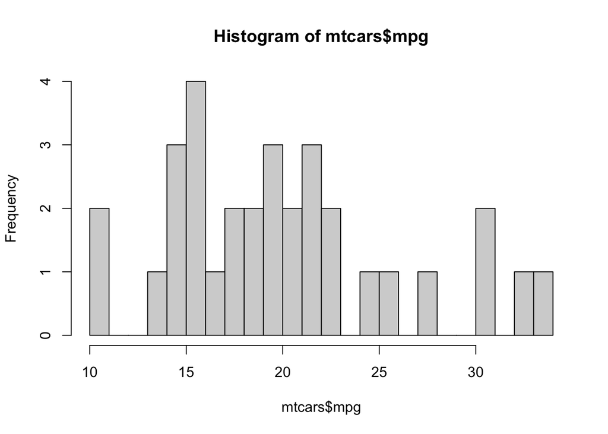

```r
hist(mtcars$mpg, breaks = 30)
```

Если же вы хотите быстро посмотреть на зависимость одной переменной от другой, можно использовать обычную функцию `plot`.

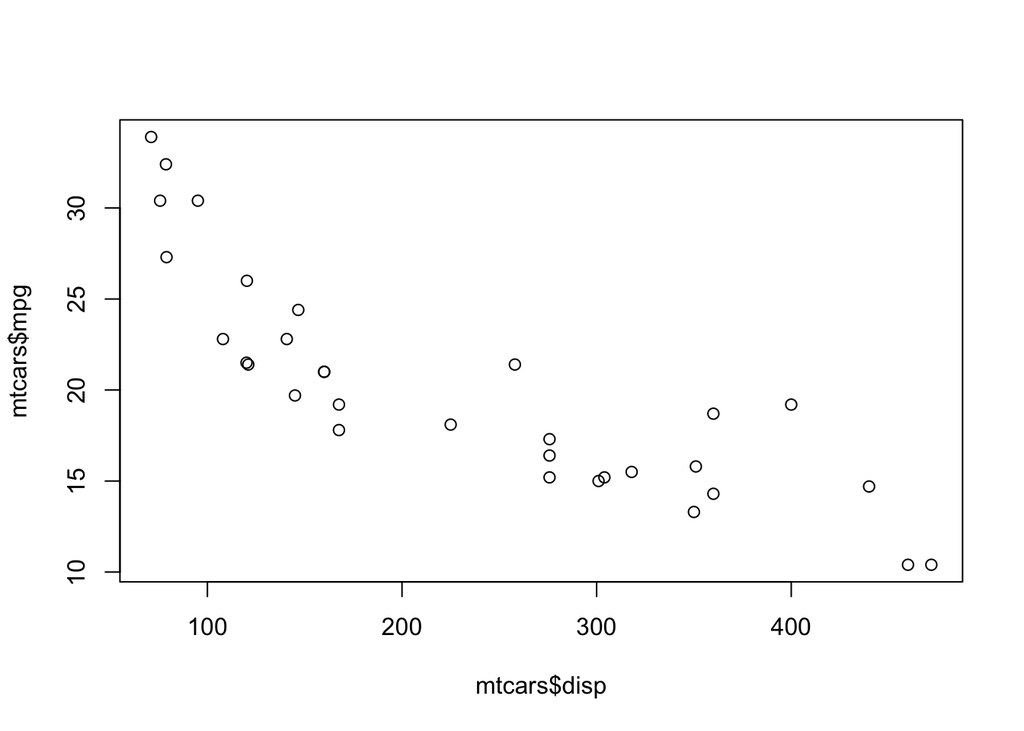

```r
plot(mtcars$disp, mtcars$mpg)
```

Данные функции так же устарели. Графики получаются некрасивыми. Поэтому в этом курсе мы будем пользоваться пакетом `ggplot2` для более продвинутой и красивой визуализации.

```r
# install.packages('ggplot2')
library('ggplot2')
```

Более подробно мы будем изучать этот пакет на следующих занятиях. А сейчас давайте изучим как построить самые простые графики.

Гистограмма распределения.

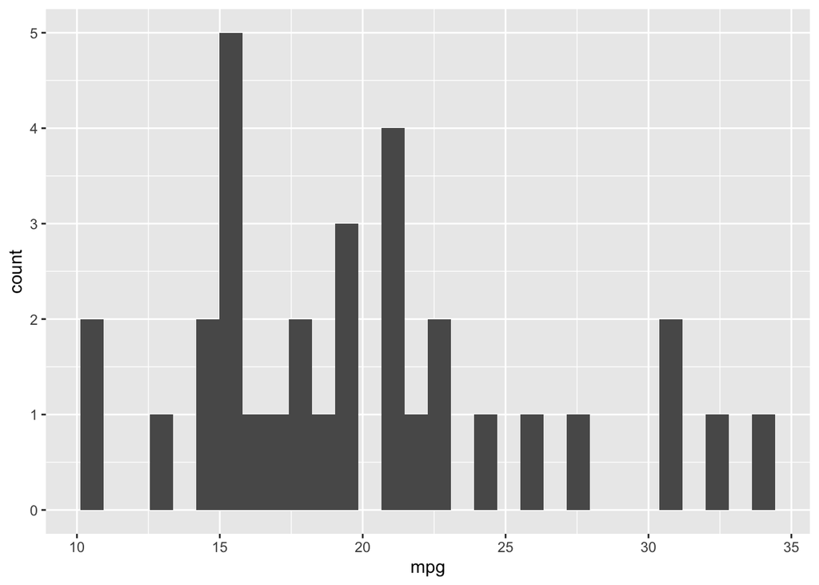

```r
ggplot(mtcars, aes(x = mpg)) +
  geom_histogram()
```

Диаграмма рассеяния.

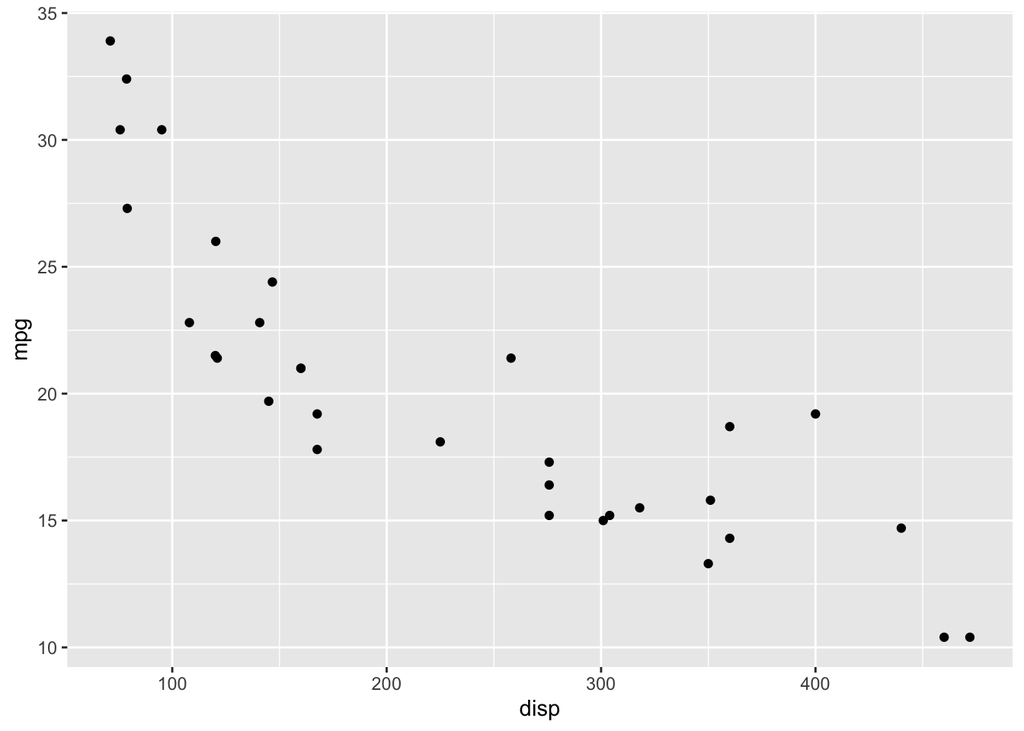

```r
ggplot(mtcars, aes(x = disp, y = mpg)) +
  geom_point()
```

### List

Список(list) – это более усложненный вариант массива. В массиве мы могли хранить набор чисел или строк. Но не могли записать в первое значение массива еще один массив или матрицу. Для этого и был придуман список. Внутри него можно хранить любые данные.

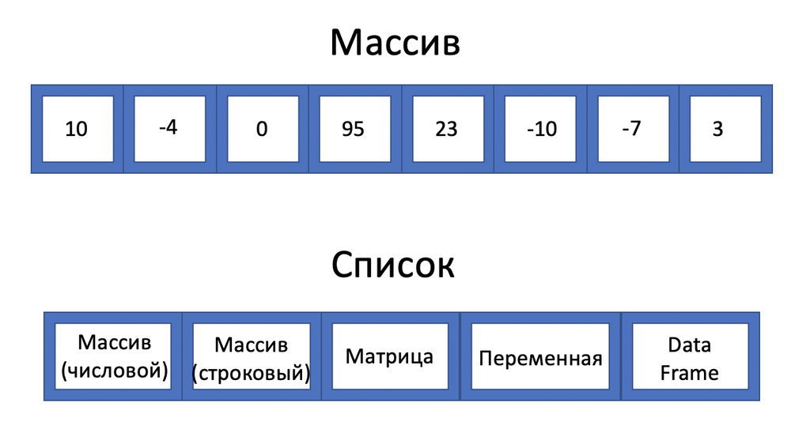

Создавать списки можно с помощью функции `list`.

```r
x <- list(1, 2, 3)
x
```

```
## [[1]]
## [1] 1
##
## [[2]]
## [1] 2
##
## [[3]]
## [1] 3
```

Можно посмотреть на структуру нашего списка с помощью уже известной нам функции `str`.

```r
str(x)
```

```
## List of 3
##  $ : num 1
##  $ : num 2
##  $ : num 3
```

Можно давать имена объектам списка.

```r
x <- list(a = 1, b = 2, c = 3)
str(x)
```

```
## List of 3
##  $ a: num 1
##  $ b: num 2
##  $ c: num 3
```

Список, который мы создали, можно было сделать и с помощью массива. Но списки могут хранить переменные разного типа.

```r
y <- list('a', TRUE, 42.24)
str(y)
```

```
## List of 3
##  $ : chr "a"
##  $ : logi TRUE
##  $ : num 42.2
```

В списках можно хранить массивы, матрицы и другие объекты.

```r
z <- list(1:10, matrix(0, 3,3))
z
```

```
## [[1]]
##  [1]  1  2  3  4  5  6  7  8  9 10
##
## [[2]]
##      [,1] [,2] [,3]
## [1,]    0    0    0
## [2,]    0    0    0
## [3,]    0    0    0
```

В списках можно хранить списки!

```r
k <- list(list(1, 2), list(3, 4), list(5, 6))
k
```

```
## [[1]]
## [[1]][[1]]
## [1] 1
##
## [[1]][[2]]
## [1] 2
##
##
## [[2]]
## [[2]][[1]]
## [1] 3
##
## [[2]][[2]]
## [1] 4
##
##
## [[3]]
## [[3]][[1]]
## [1] 5
##
## [[3]][[2]]
## [1] 6
```

```r
str(k)
```

```
## List of 3
##  $ :List of 2
##   ..$ : num 1
##   ..$ : num 2
##  $ :List of 2
##   ..$ : num 3
##   ..$ : num 4
##  $ :List of 2
##   ..$ : num 5
##   ..$ : num 6
```

Вообще список можно представить как обычный пакет. В пакете вы можете хранить какие-то вещи(переменные, массивы, матрицы и df). В этом же пакете у вас могут быть еще пакеты, внутри которых тоже что-то есть.

Есть три способа извлечения элементов списка, которые разберем на примере следующего списка.

```r
a <- list(a = 1:3, b = 'Hello', c = pi, d = list(-1, -5))
a
```

```
## $a
## [1] 1 2 3
##
## $b
## [1] "Hello"
##
## $c
## [1] 3.141593
##
## $d
## $d[[1]]
## [1] -1
##
## $d[[2]]
## [1] -5
```

- `[` – извлекает подсписок.

```r
str(a[1:2])
## List of 2
##  $ a: int [1:3] 1 2 3
##  $ b: chr "Hello"
str(a[4])
## List of 1
##  $ d:List of 2
##   ..$ : num -1
##   ..$ : num -5
```

- `[[` – извлекает одиночный компонент списка.

```r
print(a[[1]])
## [1] 1 2 3
print(a[[2]])
## [1] "Hello"
print(a[['c']])
## [1] 3.141593
```

- `$` – извлечение по имени элемента списка.

```r
print(a$b)
```

```
## [1] "Hello"
```

Разница между `[` и `[[` играет важную роль, так как `[[` проникает в список, тогда как `[` возращает новый список меньшего размера.

Объекты списка можно изменять.

```r
a[[1]] <- c(a[[1]], 4)
a[[1]][4]
```

```
## [1] 4
```

Если список состоит из одиночных элементов одного типа, при необходимости его можно быстро превратить в обычный вектор с помощью функции `unlist()`:

```r
l <- list(c("a", "b", "c"))
l
## [[1]]
## [1] "a" "b" "c"
unlist(l)
## [1] "a" "b" "c"
```